# Cyclin-Dependent Kinases Regulatory Subunit

## Figure 4: Best-cluster predicted contact maps over the two true folds.

Predicted contact maps (MSA-Transformer) for the clusters best matching each fold, over the true contacts of fold 1 (upper triangle) and fold 2 (lower). Divergent contacts between clusters are the contact-level signature of fold-switching.

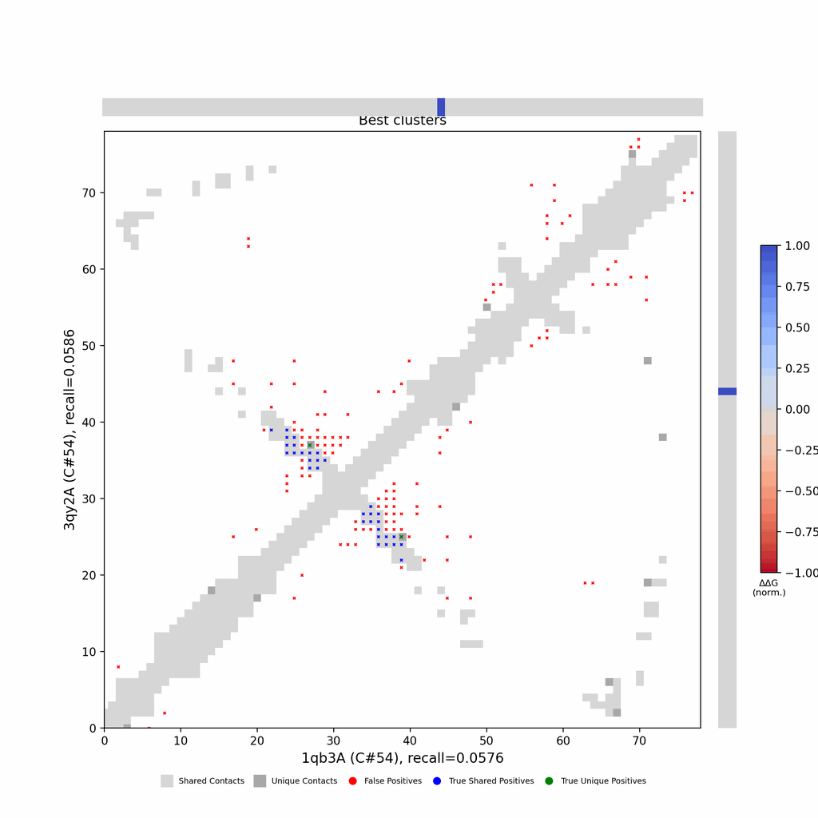

## Figure 5: Per-residue ΔΔG fold-preference contribution

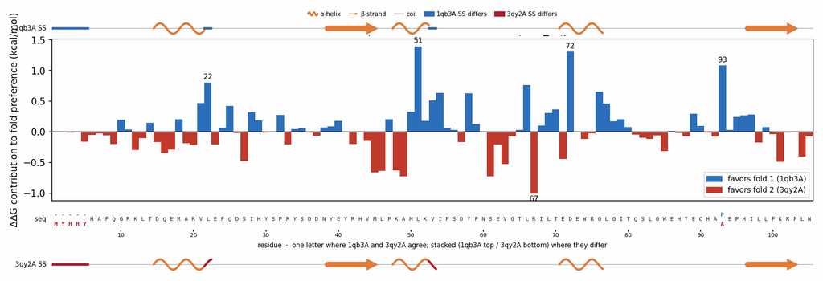

**More figures**

## Figure 6: Deep-MSA contact map panel / Best clusters contact map panel

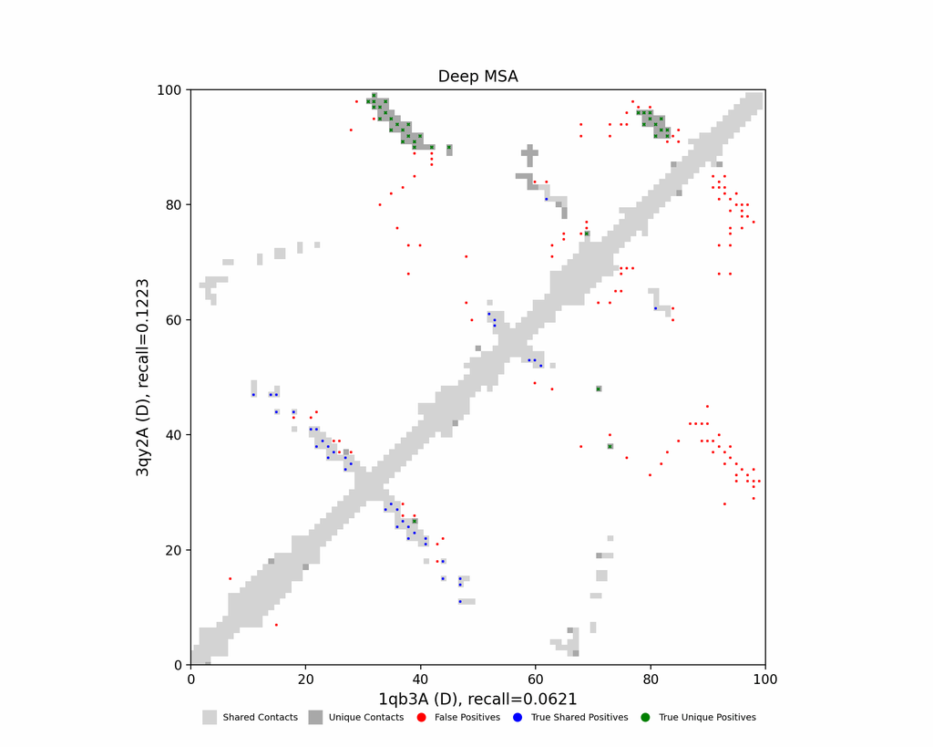

Deep-MSA contact map panel

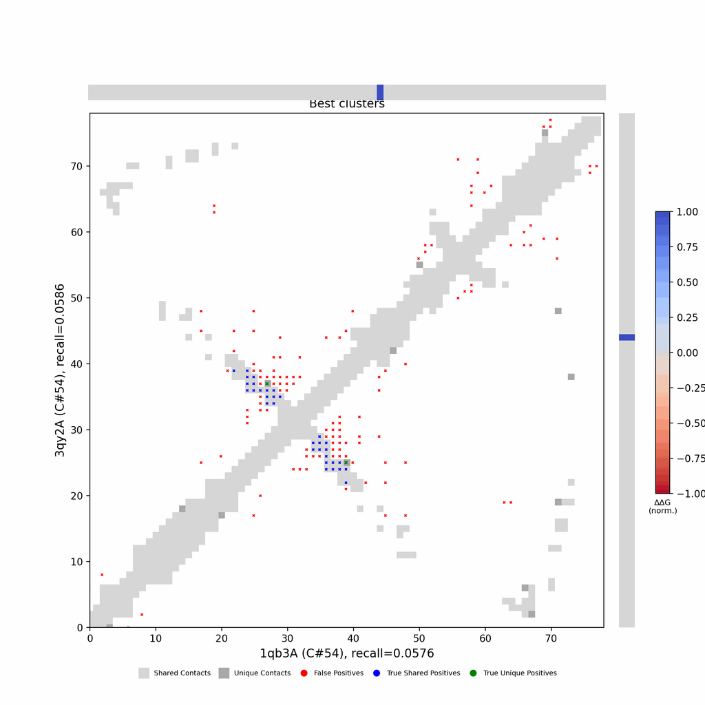

Best clusters contact map panel

## Figure 7: All clusters contact-map mosaic (small multiples).

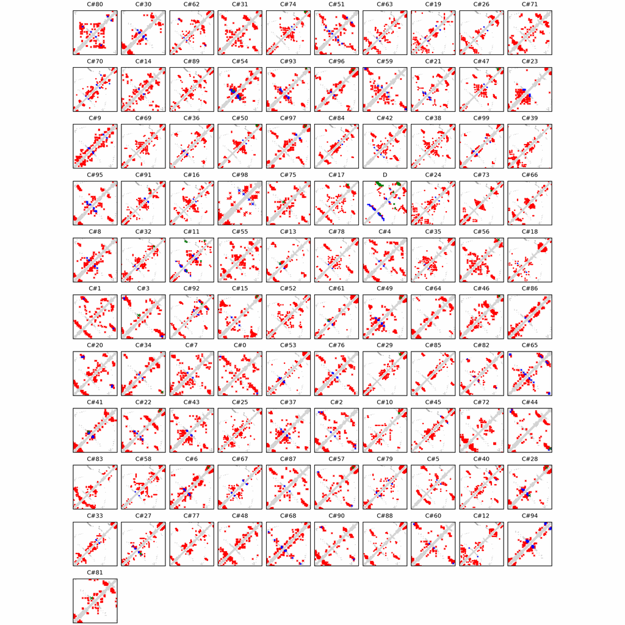

## Figure 8: Phylo null: tree with shuffled cluster fold labels.

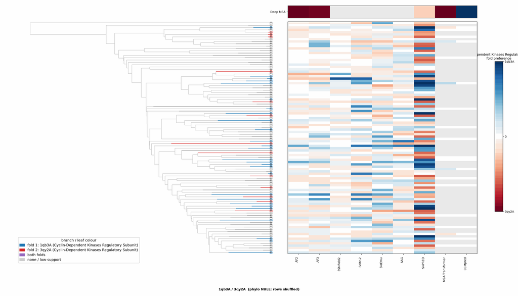

## Cluster metrics table

Per-cluster metrics underlying the figures above.

| cluster | n | neff | AF2_TM1 | AF2_TM2 | AF3_TM1 | AF3_TM2 | RE-MSAT-COM | RE-MSAT1 | RE-MSAT2 | ESM_SEQIDS | ESM_TM1 | ESM_TM2 | ΔΔG_Bias | ΔΔG_Bias_std | ΔΔG_frac_F1 | Boltz2_pref | S4PRED_pref | CCMpred_pref | BioEmu_pref |
| --- | --- | --- | --- | --- | --- | --- | --- | --- | --- | --- | --- | --- | --- | --- | --- | --- | --- | --- | --- |
| Deep | - | - | 0.73 | 0.92 | 0.74 | 0.92 | 0.16 | 0.2 | 0.39 | - | - | - | - | - | - | - | -0.02 | 0.01 | - |
| 000 | 415.0 | 133.0 | 0.42 | 0.55 | 0.37 | 0.48 | 0.0 | 0.0 | 0.0 | 005; 001; 005; 002; 001; 002; 009; 009; 003; 003 | 0.40 ± 0.04 | 0.50 ± 0.09 | 2.63 | 2.78 | 0.7 | -0.13 | -0.02 | 0.0 | -0.05 |
| 001 | 344.0 | 94.0 | 0.41 | 0.56 | 0.41 | 0.52 | 0.02 | 0.02 | 0.02 | 001; 001; 008; 008; 004; 004; 005; 005; 002; 002 | 0.37 ± 0.05 | 0.46 ± 0.08 | 4.57 | 2.52 | 1.0 | -0.13 | 0.01 | 0.0 | -0.06 |
| 002 | 214.0 | 59.0 | 0.44 | 0.54 | 0.46 | 0.57 | 0.02 | 0.02 | 0.02 | 004; 004; 005; 005; 001; 001; 006; 006; 009; 009 | 0.47 ± 0.07 | 0.59 ± 0.10 | 3.93 | 3.16 | 0.8 | -0.12 | -0.06 | 0.0 | -0.07 |
| 003 | 152.0 | 52.0 | 0.42 | 0.55 | 0.44 | 0.58 | 0.0 | 0.0 | 0.0 | 001; 001; 006; 006; 010; 010; 002; 002; 007; 007 | 0.59 ± 0.08 | 0.73 ± 0.09 | 2.39 | 3.27 | 0.7 | -0.1 | -0.04 | 0.0 | -0.08 |
| 004 | 152.0 | 48.0 | 0.4 | 0.52 | 0.23 | 0.29 | 0.0 | 0.0 | 0.0 | 010; 010; 005; 005; 009; 009; 001; 001; 003; 003 | 0.43 ± 0.05 | 0.56 ± 0.06 | 3.55 | 2.94 | 0.9 | -0.14 | 0.01 | 0.0 | -0.09 |
| 005 | 147.0 | 33.0 | 0.44 | 0.56 | 0.45 | 0.59 | 0.0 | 0.0 | 0.0 | 002; 002; 009; 001; 009; 001; 003; 003; 006; 004 | 0.39 ± 0.08 | 0.48 ± 0.14 | 3.28 | 2.4 | 1.0 | -0.08 | 0.02 | 0.0 | -0.05 |
| 006 | 135.0 | 8.0 | 0.4 | 0.52 | 0.44 | 0.56 | 0.0 | 0.0 | 0.0 | 006; 006; 005; 005; 007; 007; 004; 004; 001; 002 | 0.42 ± 0.05 | 0.55 ± 0.06 | 2.27 | 2.13 | 0.8 | -0.12 | 0.02 | 0.0 | -0.07 |
| 007 | 135.0 | 16.0 | 0.41 | 0.54 | 0.43 | 0.58 | 0.0 | 0.0 | 0.0 | 006; 006; 002; 002; 009; 009; 007; 001; 001; 007 | 0.39 ± 0.04 | 0.49 ± 0.07 | 2.09 | 4.78 | 0.6 | -0.14 | -0.01 | 0.0 | -0.06 |
| 008 | 127.0 | 30.0 | 0.42 | 0.54 | 0.45 | 0.59 | 0.0 | 0.0 | 0.0 | 010; 003; 003; 002; 002; 001; 007; 001; 007; 010 | 0.42 ± 0.01 | 0.56 ± 0.02 | 2.66 | 2.24 | 1.0 | -0.12 | -0.04 | 0.0 | -0.02 |
| 009 | 127.0 | 20.0 | 0.36 | 0.47 | 0.24 | 0.3 | 0.0 | 0.0 | 0.0 | 001; 008; 008; 001; 002; 002; 003; 003; 009; 009 | 0.37 ± 0.05 | 0.49 ± 0.07 | 4.16 | 3.94 | 0.8 | -0.14 | -0.01 | 0.0 | -0.06 |
| 010 | 118.0 | 15.0 | 0.37 | 0.49 | 0.44 | 0.58 | 0.0 | 0.0 | 0.0 | 001; 001; 008; 008; 010; 010; 009; 009; 003; 003 | 0.51 ± 0.04 | 0.65 ± 0.05 | 2.1 | 2.39 | 0.8 | -0.14 | -0.06 | 0.0 | -0.06 |
| 011 | 102.0 | 12.0 | 0.58 | 0.72 | 0.65 | 0.79 | 0.0 | 0.0 | 0.0 | 002; 002; 005; 005; 001; 001; 003; 003; 004; 004 | 0.41 ± 0.03 | 0.52 ± 0.04 | 4.66 | 3.23 | 1.0 | -0.1 | 0.04 | 0.0 | -0.05 |
| 012 | 96.0 | 1.0 | 0.52 | 0.63 | 0.31 | 0.36 | 0.0 | 0.0 | 0.0 | 009; 001; 009; 010; 001; 002; 002; 010; 004; 008 | 0.35 ± 0.02 | 0.43 ± 0.06 | 2.88 | 1.67 | 1.0 | -0.05 | 0.06 | 0.0 | -0.09 |
| 013 | 95.0 | 37.0 | 0.39 | 0.47 | 0.38 | 0.5 | 0.0 | 0.0 | 0.0 | 002; 002; 001; 001; 005; 005; 006; 006; 004; 003 | 0.42 ± 0.04 | 0.55 ± 0.04 | 3.17 | 1.98 | 1.0 | -0.11 | -0.06 | 0.0 | -0.07 |
| 014 | 93.0 | 16.0 | 0.38 | 0.49 | 0.25 | 0.33 | 0.0 | 0.0 | 0.0 | 008; 008; 004; 004; 002; 003; 003; 002; 001; 001 | 0.38 ± 0.04 | 0.51 ± 0.04 | 2.63 | 2.79 | 0.9 | -0.13 | 0.05 | 0.0 | -0.06 |
| 015 | 90.0 | 6.0 | 0.41 | 0.53 | 0.45 | 0.57 | 0.0 | 0.0 | 0.0 | 006; 006; 007; 007; 001; 001; 003; 004; 004; 003 | 0.45 ± 0.03 | 0.58 ± 0.05 | 0.94 | 2.28 | 0.5 | -0.12 | -0.06 | 0.0 | -0.06 |
| 016 | 86.0 | 21.0 | 0.51 | 0.66 | 0.45 | 0.58 | 0.0 | 0.0 | 0.0 | 001; 001; 005; 005; 009; 009; 004; 003; 004; 008 | 0.41 ± 0.03 | 0.54 ± 0.03 | 4.75 | 2.18 | 1.0 | -0.12 | 0.04 | 0.0 | -0.07 |
| 017 | 84.0 | 31.0 | 0.35 | 0.45 | 0.51 | 0.66 | 0.0 | 0.0 | 0.0 | 008; 008; 005; 005; 001; 001; 007; 007; 006; 004 | 0.46 ± 0.07 | 0.58 ± 0.10 | 5.71 | 3.32 | 1.0 | -0.11 | 0.0 | 0.0 | -0.04 |
| 018 | 75.0 | 2.0 | 0.5 | 0.62 | 0.52 | 0.6 | 0.0 | 0.0 | 0.0 | 005; 005; 007; 007; 001; 001; 006; 004; 010; 008 | 0.36 ± 0.06 | 0.45 ± 0.12 | 3.32 | 0.54 | 1.0 | -0.12 | 0.06 | 0.0 | -0.07 |
| 019 | 71.0 | 2.0 | 0.52 | 0.64 | 0.69 | 0.86 | 0.0 | 0.0 | 0.0 | 004; 004; 002; 002; 001; 009; 001; 005; 009; 005 | 0.43 ± 0.01 | 0.56 ± 0.01 | 3.26 | 1.98 | 1.0 | -0.09 | 0.0 | 0.0 | -0.06 |
| 020 | 67.0 | 21.0 | 0.4 | 0.5 | 0.44 | 0.58 | 0.0 | 0.0 | 0.0 | - | - | - | 3.49 | 3.54 | 0.9 | -0.12 | -0.05 | - | -0.05 |
| 021 | 67.0 | 24.0 | 0.43 | 0.57 | 0.44 | 0.58 | 0.02 | 0.02 | 0.02 | - | - | - | 4.67 | 3.22 | 0.9 | -0.11 | 0.01 | - | -0.04 |
| 022 | 67.0 | 9.0 | 0.42 | 0.53 | 0.45 | 0.58 | 0.08 | 0.07 | 0.07 | - | - | - | 3.34 | 1.83 | 1.0 | -0.12 | -0.06 | - | -0.08 |
| 023 | 66.0 | 5.0 | 0.38 | 0.47 | 0.45 | 0.59 | 0.0 | 0.0 | 0.0 | - | - | - | 1.02 | 2.37 | 0.6 | -0.02 | -0.02 | - | -0.02 |
| 024 | 65.0 | 6.0 | 0.61 | 0.75 | 0.52 | 0.65 | 0.0 | 0.0 | 0.0 | - | - | - | 3.76 | 1.49 | 1.0 | -0.13 | 0.06 | - | -0.08 |
| 025 | 63.0 | 19.0 | 0.43 | 0.54 | 0.38 | 0.48 | 0.0 | 0.0 | 0.0 | - | - | - | 1.64 | 2.0 | 0.7 | -0.11 | 0.03 | - | -0.1 |
| 026 | 62.0 | 10.0 | 0.48 | 0.58 | 0.33 | 0.47 | 0.02 | 0.02 | 0.01 | - | - | - | 2.83 | 1.76 | 1.0 | -0.04 | 0.06 | - | -0.08 |
| 027 | 61.0 | 6.0 | 0.46 | 0.57 | 0.37 | 0.49 | 0.0 | 0.0 | 0.0 | - | - | - | 1.61 | 2.62 | 0.8 | -0.12 | -0.02 | - | -0.05 |
| 028 | 61.0 | 16.0 | 0.36 | 0.47 | 0.37 | 0.46 | 0.0 | 0.03 | 0.0 | - | - | - | 1.69 | 1.83 | 0.8 | -0.1 | -0.02 | - | -0.03 |

[output cut: 71 more lines]